# Impact de la publicité multi-canal sur les ventes

[figure not shown]

**Auteurs: “KOUASSI CYRUS & MAHAMAT ABDOULAYE”**

Date : 03/04/2025

# Introduction

**Contexte**

Dans un marché hautement concurrentiel, les entreprises investissent massivement dans des campagnes publicitaires sur divers canaux, notamment la télévision, la radio, les promotions en magasin et les annonces en ligne. Cependant, toutes les stratégies de communication ne génèrent pas le même impact sur les ventes. Un mauvais ciblage ou une répartition inefficace du budget marketing peut conduire à des dépenses inutiles sans retour sur investissement (ROI) significatif.

**L’objectif** de cette étude est d’identifier les canaux publicitaires qui contribuent le plus efficacement à l’augmentation des ventes.

**Problématique :Quels caneaux publicitaires sont les plus efficaces pour augmenter les ventes ?**

Contenu de la dataset :

Elle Comprend des informations sur un produit spécifique d’une marque non divulguée. Chaque ligne de l’ensemble de données représente le volume des ventes sur une semaine, ainsi que des détails sur les campagnes marketing et les méthodes promotionnelles utilisées pour le produit tout au long de la période de deux ans. Le produit spécifique et les années correspondantes pour ces données restent inconnus.

La base de données comporte **992 obeservations et 8 variables**. Elles sont toutes des **variables quantitatives**:

- Sale → le nombre de ventes de produits pour chaque semaine observée.
- InStrSpending → dépenses moyennes associées à la promotion du produit en magasin pour la semaine observée.
- Discount → Le taux de remise applicable pour la semaine observée.
- TVSpending → dépenses moyennes en campagnes télévisées au cours de la semaine observée.
- StockRate → taux de rupture de stock, calculé comme le nombre de fois où le produit a été en rupture de stock divisé par le nombre total de visites du produit.
- Price → le prix de base hebdomadaire observé pour le produit
- Radio → Le nombre de publicités ou de campagnes radio faisant la promotion du produit pour la semaine observée.
- OnlineAdsSpending → dépenses publicitaires en ligne, calculant le montant total des dépenses en publicité en ligne.

NB: toutes les valeurs de prix calculées sont basées sur le dollar américain (USD).

**Source:** https://www.kaggle.com/datasets/ai0909/sales-data-for-company-product

**Auteur**: **Eine mögliche**, Data Scientist

# Partie I: Explorations et Traitements

## I. Analyse exploratoire

|  | Sale | InStrSpending | Discount | TVSpending | StockRate | Price | Radio | OnlineAdsSpending |
| --- | --- | --- | --- | --- | --- | --- | --- | --- |
| 1 | 240368 | 59.90 | 0.46 | 46.30 | 0.45 | 12.56 | 1065 | 1081.60 |
| 2 | 207276 | 7.28 | 0.39 | 166.91 | 0.05 | 5.44 | 1832 | 651.24 |
| 3 | 172572 | 9.81 | 0.41 | 73.67 | 0.06 | 3.54 | 587 | 1066.56 |
| 4 | 82697 | 46.94 | 0.27 | 33.95 | 0.88 | 28.90 | 1407 | 1855.27 |
| 5 | 141762 | 2.59 | 0.26 | 82.63 | 0.36 | 4.66 | 2057 | 1608.91 |
| 6 | 271990 | 57.08 | 0.17 | 160.76 | 0.93 | 15.60 | 1723 | 2916.29 |

Pour améliorer la lisibilité et la compréhension de notre jeu de données, nous avons renommé les colonnes en utilisant des noms plus explicites. ***

```
## [1] "Ventes"             "Depenses_Magasin"   "Remise"
## [4] "Depenses_TV"        "Taux_Rupture_Stock" "Prix"
## [7] "Publicites_Radio"   "Depenses_En_Ligne"
```

## I.1 Resumé statistiques des données

### Dimension de nos données

```
## [1] 992   8
```

### Structure des données

```
## 'data.frame':    992 obs. of  8 variables:
##  $ Ventes            : int  240368 207276 172572 82697 141762 271990 186979 176084 98234 262918 ...
##  $ Depenses_Magasin  : num  59.9 7.28 9.81 46.94 2.59 ...
##  $ Remise            : num  0.46 0.39 0.41 0.27 0.26 0.17 0.25 0.07 0.41 0.24 ...
##  $ Depenses_TV       : num  46.3 166.9 73.7 34 82.6 ...
##  $ Taux_Rupture_Stock: num  0.45 0.05 0.06 0.88 0.36 0.93 0.61 0.18 0.04 0.76 ...
##  $ Prix              : num  12.56 5.44 3.54 28.9 4.66 ...
##  $ Publicites_Radio  : int  1065 1832 587 1407 2057 1723 1345 847 281 2577 ...
##  $ Depenses_En_Ligne : num  1082 651 1067 1855 1609 ...
```

### Statistques descriptives

```
##      Ventes       Depenses_Magasin     Remise        Depenses_TV
##  Min.   :  1992   Min.   : 0.19    Min.   :0.0000   Min.   :  0.13
##  1st Qu.:112479   1st Qu.:14.83    1st Qu.:0.1300   1st Qu.: 49.64
##  Median :170391   Median :31.39    Median :0.2500   Median : 97.51
##  Mean   :171327   Mean   :30.59    Mean   :0.2511   Mean   : 98.68
##  3rd Qu.:226027   3rd Qu.:45.66    3rd Qu.:0.3800   3rd Qu.:147.62
##  Max.   :393914   Max.   :59.96    Max.   :0.5000   Max.   :199.91
##  Taux_Rupture_Stock      Prix        Publicites_Radio Depenses_En_Ligne
##  Min.   :0.0000     Min.   : 0.140   Min.   :   4.0   Min.   :  12.54
##  1st Qu.:0.2500     1st Qu.: 6.918   1st Qu.: 708.2   1st Qu.: 786.33
##  Median :0.4900     Median :14.820   Median :1413.5   Median :1595.45
##  Mean   :0.4945     Mean   :14.600   Mean   :1479.6   Mean   :1596.50
##  3rd Qu.:0.7400     3rd Qu.:22.100   3rd Qu.:2273.0   3rd Qu.:2420.69
##  Max.   :1.0000     Max.   :29.990   Max.   :2997.0   Max.   :3198.27
```

Notre base contient 8 colonnes et 992 Observations, toutes nos variables sont quantitatifs.

## I.2 Vérification et visualisation des valeurs manquantes

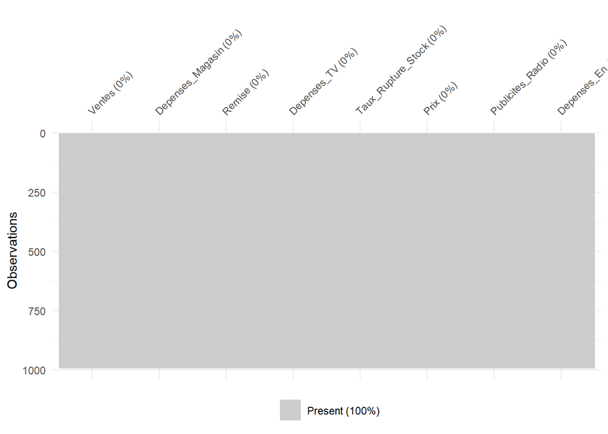

Il n’y a **pas de données manquants** dans notre base de donnée.

## I.3 Analyses univariées: Distribution des variables

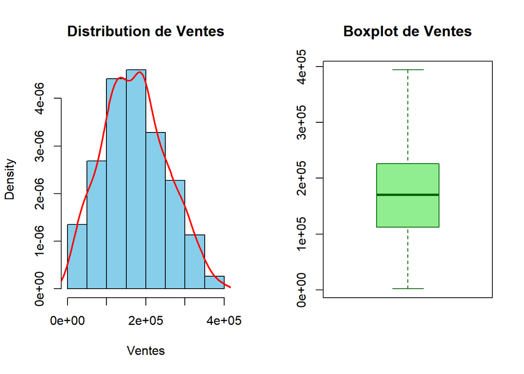

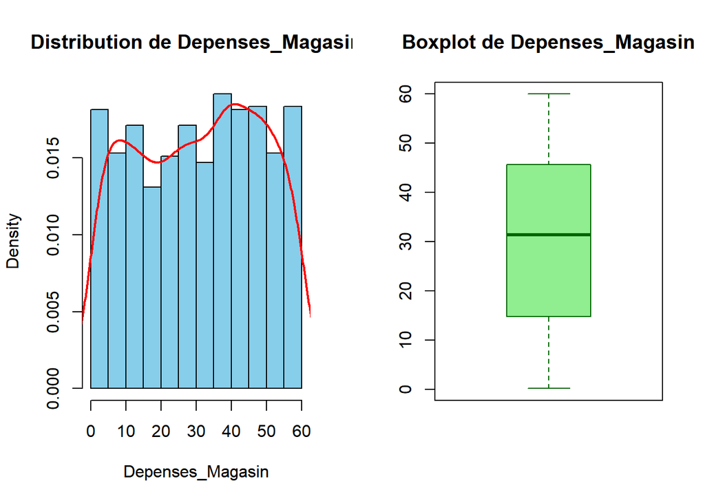

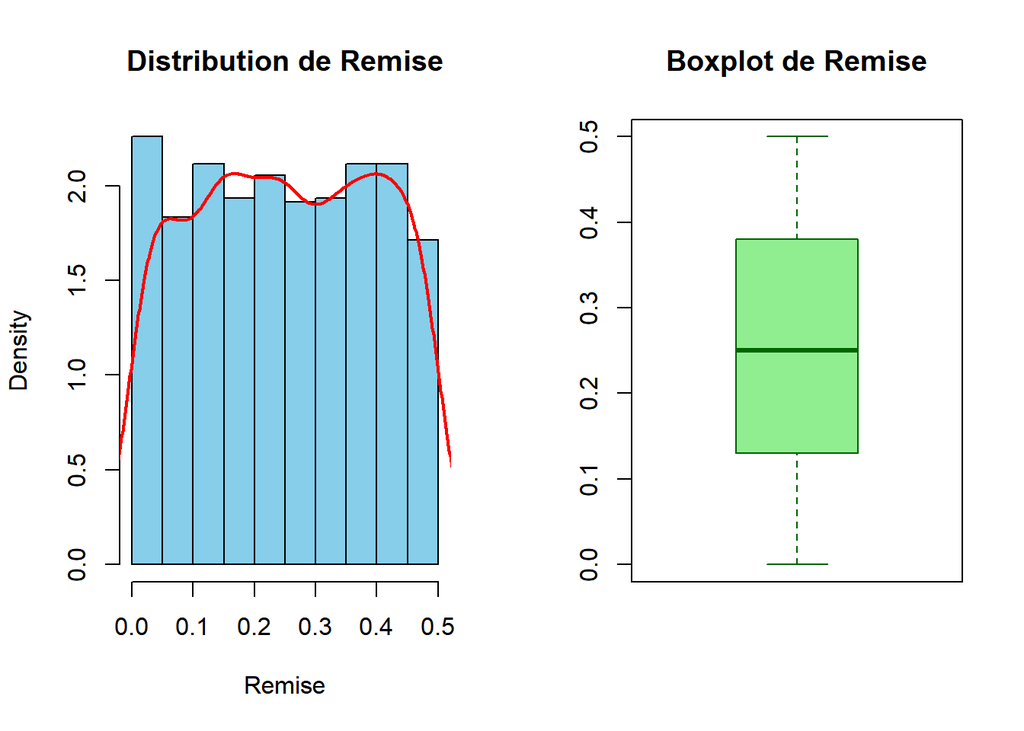

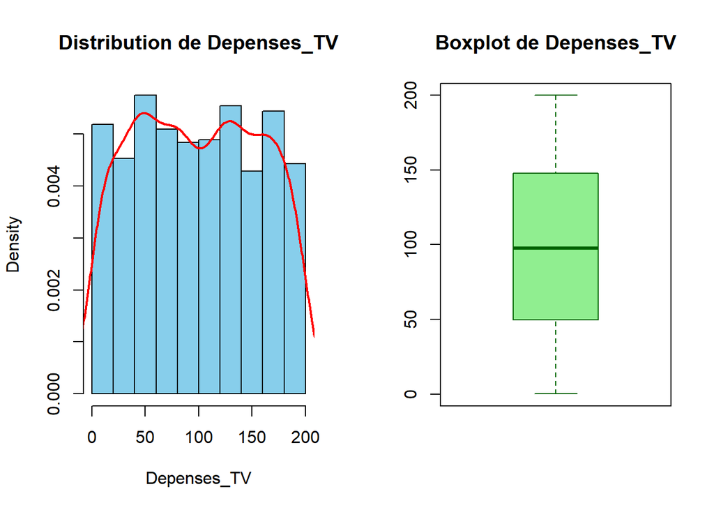

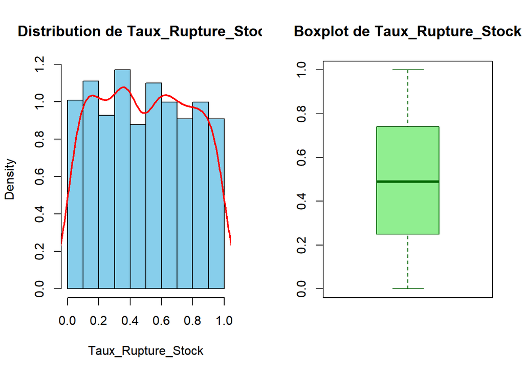

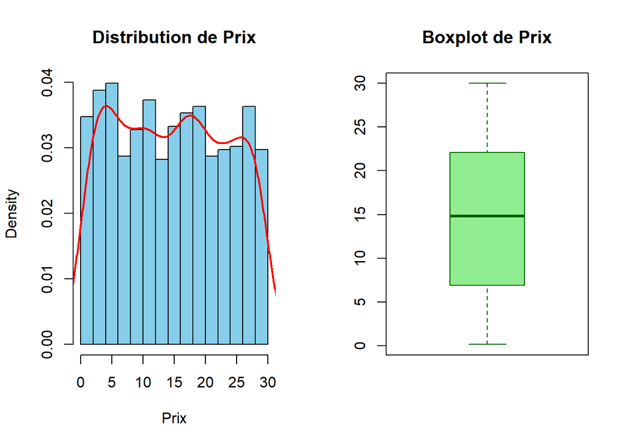

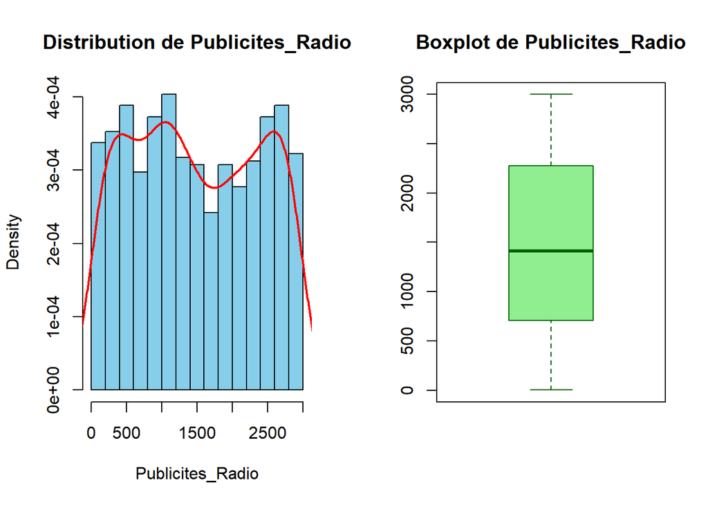

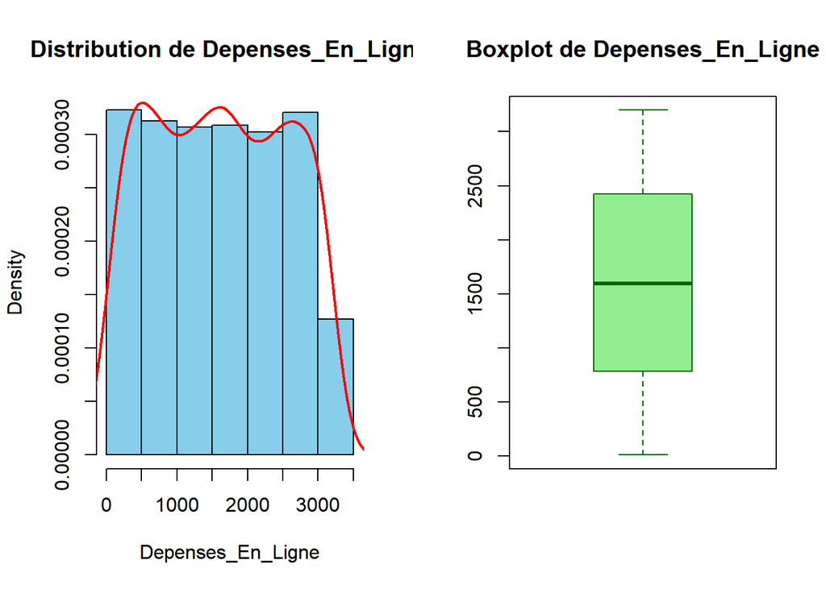

L’analyse des boxplots révèle **l’absence de valeurs aberrantes ou extrêmes** dans notre jeu de données. De plus, l’examen des histogrammes pour chaque variable montre une distribution symétrique, indiquant une répartition équilibrée des données autour de la moyenne. Cette symétrie et l’absence de valeurs extrêmes suggèrent une bonne qualité et une cohérence dans nos données, ce qui renforce la fiabilité de nos analyses ultérieures et minimise le risque de biais dus à des observations atypiques.

## I.4 Corrélation entre les variables

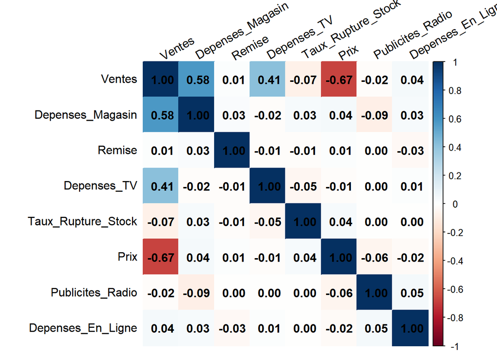

**Corrélations fortes:** Les variables Sales et Price sont négativement corrélées (-0.67), ce qui signifie que lorsque le prix augmente, les ventes ont tendance à diminuer.

Les variables Sales et InStrSpending sont positivement corrélées (0.58), cela indique que l’augmentation des dépenses en stratégie interne (probablement marketing ou publicité) favorise une hausse des ventes.

**Corrélations modérées:** Les variables Sales et TVSpending présentent une corrélation positive modérée (0.41), suggérant que les dépenses en publicité télévisée influencent les ventes, mais avec un effet limité.

Enfin, les variables InStrSpending et Sales (0.58) confirment que les investissements en publicité interne ont un impact significatif sur l’augmentation des ventes

## II. Analyse en composante principale

Dans une analyse de données, la régression permet d’expliquer ou de prédire une variable cible en fonction d’un ensemble de variables explicatives. Cependant, lorsque ces variables sont nombreuses et potentiellement corrélées entre elles, plusieurs problèmes peuvent apparaître, rendant la régression moins fiable. C’est dans ce contexte que l’Analyse en Composantes Principales (ACP) joue un rôle clé. L’ACP permet de résumer l’information contenue dans plusieurs variables en un nombre réduit de composantes principales tout en conservant un maximum de variance.

Dans notre projet, **l’ACP est utilisée comme un prétraitement avant la régression** pour :

- Identifier les variables les plus influentes.
- Réduire le nombre de variables explicatives tout en conservant l’essentiel de l’information.
- Améliorer la stabilité du modèle de régression en limitant les problèmes de corrélation entre variables.
- Fournir une meilleure compréhension des relations entre les variables et leur impact sur les ventes.

```
##
## Call:
## PCA(X = base, scale.unit = TRUE, graph = FALSE)
##
##
## Eigenvalues
##                        Dim.1   Dim.2   Dim.3   Dim.4   Dim.5   Dim.6   Dim.7
## Variance               1.969   1.150   1.044   1.013   0.985   0.955   0.883
## % of var.             24.618  14.375  13.047  12.666  12.308  11.941  11.035
## Cumulative % of var.  24.618  38.993  52.040  64.706  77.014  88.956  99.991
##                        Dim.8
## Variance               0.001
## % of var.              0.009
## Cumulative % of var. 100.000
##
## Individuals (the 10 first)
##                        Dist    Dim.1    ctr   cos2    Dim.2    ctr   cos2
## 1                  |  2.654 |  1.099  0.062  0.171 |  1.680  0.247  0.401 |
## 2                  |  3.004 |  0.713  0.026  0.056 | -1.684  0.249  0.314 |
## 3                  |  2.838 |  0.121  0.001  0.002 | -0.689  0.042  0.059 |
## 4                  |  2.820 | -1.623  0.135  0.331 |  1.754  0.270  0.387 |
## 5                  |  2.174 | -0.405  0.008  0.035 | -1.877  0.309  0.745 |
## 6                  |  3.122 |  1.724  0.152  0.305 |  0.736  0.048  0.056 |
## 7                  |  1.324 |  0.257  0.003  0.038 |  0.456  0.018  0.119 |
## 8                  |  2.086 |  0.139  0.001  0.004 |  0.351  0.011  0.028 |
## 9                  |  3.233 | -1.191  0.073  0.136 | -0.309  0.008  0.009 |
## 10                 |  2.914 |  1.479  0.112  0.258 |  0.267  0.006  0.008 |
##                     Dim.3    ctr   cos2
## 1                  -0.470  0.021  0.031 |
## 2                  -2.356  0.536  0.615 |
## 3                  -1.929  0.359  0.462 |
## 4                   1.300  0.163  0.212 |
## 5                  -0.368  0.013  0.029 |
## 6                   1.962  0.372  0.395 |
## 7                   0.726  0.051  0.301 |
## 8                  -0.270  0.007  0.017 |
## 9                  -1.905  0.350  0.347 |
## 10                  0.335  0.011  0.013 |
##
## Variables
##                       Dim.1    ctr   cos2    Dim.2    ctr   cos2    Dim.3
## Ventes             |  0.998 50.587  0.996 |  0.024  0.052  0.001 |  0.002
## Depenses_Magasin   |  0.557 15.764  0.310 |  0.654 37.224  0.428 |  0.233
## Remise             |  0.011  0.007  0.000 |  0.211  3.884  0.045 | -0.425
## Depenses_TV        |  0.430  9.393  0.185 | -0.165  2.356  0.027 | -0.302
## Taux_Rupture_Stock | -0.103  0.534  0.011 |  0.275  6.573  0.076 |  0.514
## Prix               | -0.678 23.334  0.460 |  0.432 16.223  0.187 | -0.014
## Publicites_Radio   | -0.024  0.029  0.001 | -0.600 31.276  0.360 |  0.238
## Depenses_En_Ligne  |  0.083  0.352  0.007 | -0.167  2.412  0.028 |  0.629
##                       ctr   cos2
## Ventes              0.000  0.000 |
## Depenses_Magasin    5.192  0.054 |
## Remise             17.345  0.181 |
## Depenses_TV         8.745  0.091 |
## Taux_Rupture_Stock 25.320  0.264 |
## Prix                0.018  0.000 |
## Publicites_Radio    5.420  0.057 |
## Depenses_En_Ligne  37.960  0.396 |
```

## II.1 Choix des dimensions

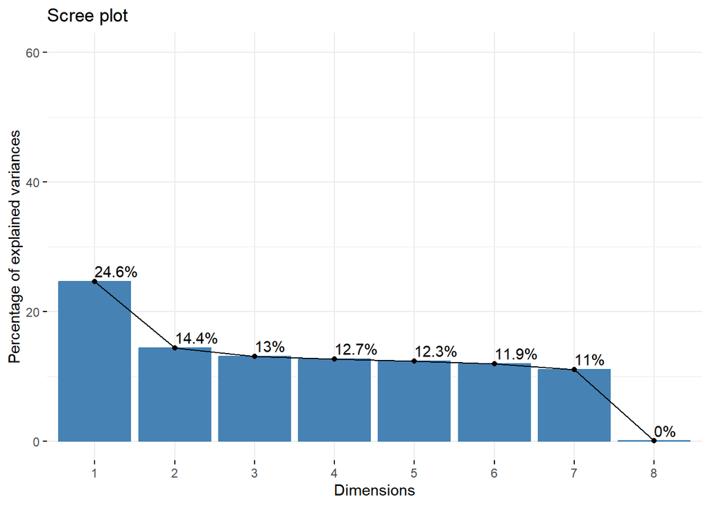

Nous voyons sur le graphique les 6 premières dimensions expliquent presque 90 % de la variance ce qui signifie signifie que ces 6 composantes principales contiennent quasiment toute l’information initiale présente dans tes données.

## II.2 Cercle de corrélation

**Visualisation sur les Dimension 1 et 2**

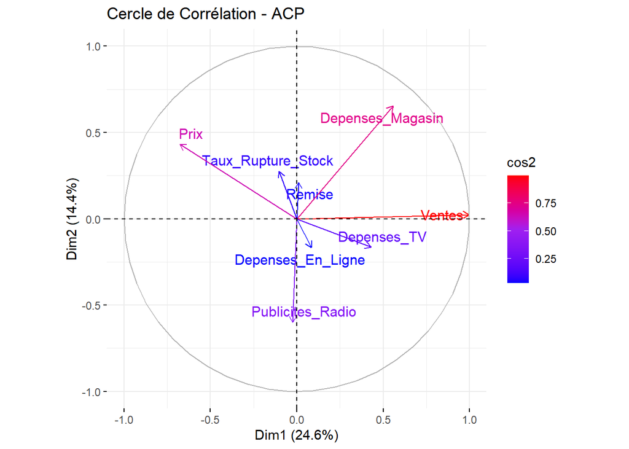

**Interprétation :**

- Les variables fortement corrélées à Dim1 : Ventes, Dépenses_Magasin

Cela suggère que Dim1 représente une intensité d’activité commerciale en magasin.

**Visualisaion sur les dimensions 2 et 3**

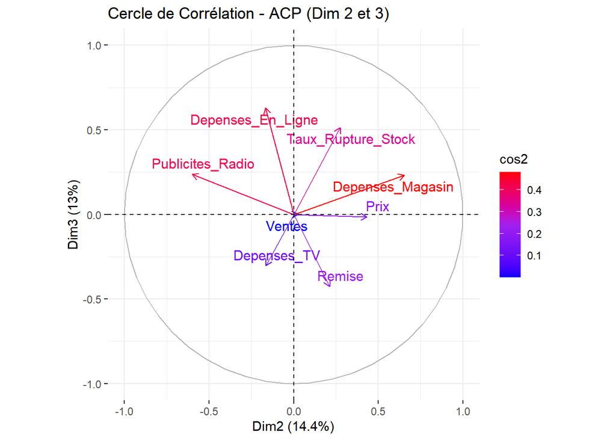

**Interprétation :**

Dim2 semble refléter une dimension canal de communication et gestion opérationnelle.

## II.3 Contribution des variables aux axes

**AXE1**

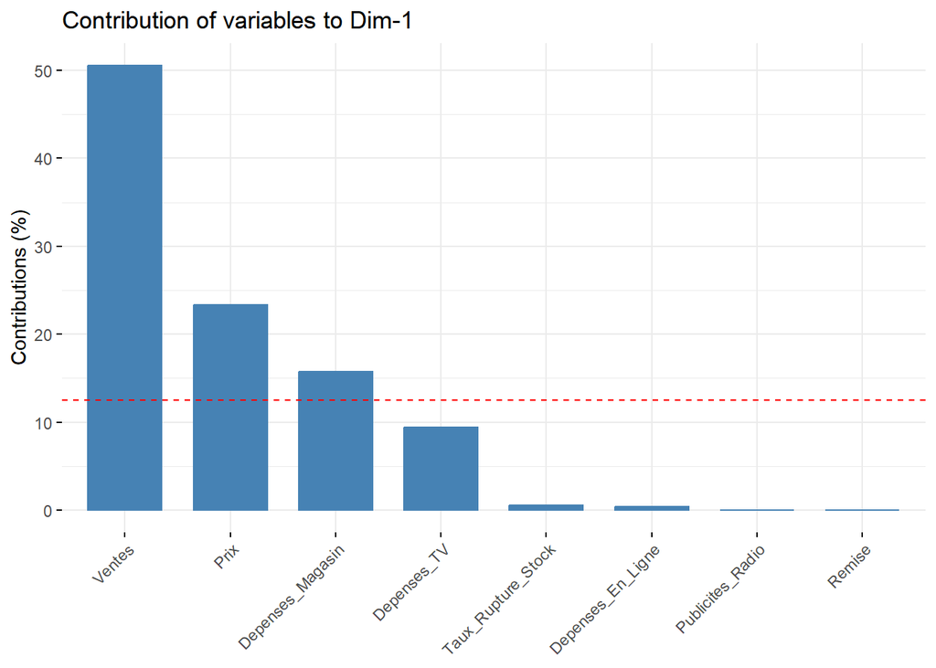

La dimension 1 est principalement influencé par les ventes, le prix et les dépenses en magasin car la variable ventes est la variable qui contribue le plus à la dimension 1 (+ 50%) mais Le prix et les dépenses en magasin jouent également un rôle important.

**AXE 2**

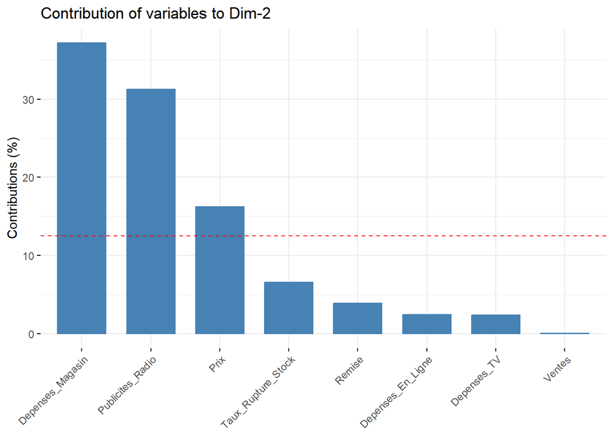

La dimension 2 est plus influencée par les dépenses en magasin et la publicité radio, ce qui suggère qu’il pourrait capturer des effets liés aux actions marketing et commerciales. Les ventes et les dépenses en ligne ont une influence négligeable sur cette dimension.

# Partie II : Modèle linéaire (LM)

## I. Proposition du model linéaire

Notre modèle de régression linéaire multiple se présente comme suit :

Y : - Ventes

X : - Depenses_Magasin - Publicites_Radio - Prix - Taux_Rupture_Stock - Remise - Depenses_En_ligne - Depenses_TV

Le modèle s’écrit sous forme matricielle ::

$$Y = X.A + ε \leftrightarrow
\left(\begin{array}{cc}y_{1}\\ y_{2} \\ .\\.\\. \\ y_{n}
\end{array}\right)
=
\left(\begin{array}{cc} 1 & x_{1,1} & ... & x_{1,p}\\ .
& .& . & .\\ . &. &. &.\\ .&. & .
&.\\ 1 & x_{n,1} & ... & x_{n,p} \end{array}\right)
\left(\begin{array}{cc} a_{0}\\ a_{1} \\ .\\.\\ . \\ a_{p}
\end{array}\right)
+
\left(\begin{array}{cc} ε_{1}\\ ε_{2} \\ .\\.\\. \\ ε_{n}
\end{array}\right)$$

Où :

- Y est le vecteur des ventes (n x 1)
- X est la matrice des variables explicatives (n x (p+1))
- A est le vecteur des coefficients de régression ((p+1) x 1)
- ε est le vecteur des termes d’erreur (n x 1)

## II.2 Hypothèses

Il y a plusieurs hypothèses à vérifier.

1. Non-nullité des corrélations : corr(X, Y) ≠ 0
2. La matrice X doit être de plein rang, assurant que X’X est inversible.
3. E(εi) = 0 et σ²(εi) = σ² (ce qui équivaut à var(ε) = σ²In) et que les εi sont non-corrélés et cov(Xi, εi) = 0. — ou plus strictement εi i.i.d. et indépendant de Xi.
4. Les εi sont de variable aléatoires normales.

### Hypothèses a priori

1. La matrice de corrélation précédemment analysée confirme des coefficients de corrélation non nuls entre les variables explicatives et la variable dépendante.
2. Indépendance linéaire des variables explicatives : Nous allons calculés le déterminant.

```
## [1] "Déterminant de X'X : 8.08112775009545e+40"
```

**Le déterminant** de X’X est **non nul**, ce qui signifie que la matrice est **inversible**. Cela confirme l’absence de multicolinéarité parfaite entre les variables explicatives, garantissant ainsi que l’estimateur des moindres carrés ordinaires (MCO) est bien défini et unique.

### Hypothèses a posteriori

3. Propriétés des termes d’erreur :
- E(εi) = 0 : espérance nulle des résidus
- σ²(εi) = σ² : homoscédasticité (variance constante des résidus)
- Cov(εi, εj) = 0 pour i ≠ j : non-corrélation des résidus
- Cov(Xi, εi) = 0 : indépendance entre les variables explicatives et les résidus
4. Normalité des résidus : Les εi suivent une distribution normale

Ces hypothèses a posteriori seront vérifiées après l’estimation du modèle, à travers l’analyse des résidus et des tests statistiques appropriés.

## III. Estimation du modèle de regression linéaire

## III.1 Estimateur des moindres carrés ordinaires

Un **estimateur** $\hat{A}$ du vecteur $A$ peut être déterminé en utilisant la **méthode des moindres carrés ordinaires (MCO)**, qui repose sur l’hypothèse numéro 2.

L’objectif est de **trouver les coefficients du vecteur** $A$ qui minimisent la somme des carrés des écarts entre les valeurs observées et celles prédites.

L’estimateur des moindres carrés est donné par :

$$\hat{A} = (X^{T}X)^{-1}X^{T}Y$$

```
## [1] "Coefficients estimés A :"
```

```
##                           [,1]
## Depenses_Magasin    3431.35679
## Remise             73304.11391
## Depenses_TV          775.01213
## Taux_Rupture_Stock 20691.00700
## Prix               -5382.69546
## Publicites_Radio      11.95693
## Depenses_En_Ligne     10.29547
```

## III.2 Détermination des résidus

L’erreur $\epsilon$ (résidu) représente l’écart entre la valeur observée $Y$ et la valeur prédite $\hat{Y}$ par le modèle. Elle est définie par la relation suivante :

$$\epsilon = Y - \hat{Y}$$

où :  
- $Y$ est le vecteur des valeurs observées,  
- $\hat{Y}$ est le vecteur des valeurs prédites obtenu à partir du modèle,  
- $\epsilon$ est le vecteur des erreurs de prédiction (résidus).

L’estimation de $\hat{Y}$ est donnée par :

$$\hat{Y} = X \hat{A}$$

où $\hat{A}$ représente le vecteur des coefficients estimés par la méthode des moindres carrés ordinaires (MCO).

## IV. Création du modèle

Nous modélisons `ventes` en fonction de toutes les autres variables explicatives.

```
##
## Call:
## lm(formula = Ventes ~ ., data = base)
##
## Residuals:
##     Min      1Q  Median      3Q     Max
## -7339.0 -2138.2  -559.3  1357.2 15604.7
##
## Coefficients:
##                      Estimate Std. Error  t value Pr(>|t|)
## (Intercept)         1.254e+05  4.685e+02  267.625  < 2e-16 ***
## Depenses_Magasin    2.875e+03  5.745e+00  500.406  < 2e-16 ***
## Remise              3.919e+03  6.879e+02    5.696 1.62e-08 ***
## Depenses_TV         5.890e+02  1.751e+00  336.410  < 2e-16 ***
## Taux_Rupture_Stock -1.357e+04  3.490e+02  -38.896  < 2e-16 ***
## Prix               -6.480e+03  1.150e+01 -563.633  < 2e-16 ***
## Publicites_Radio    6.234e-02  1.135e-01    0.549    0.583
## Depenses_En_Ligne   6.712e-02  1.080e-01    0.622    0.534
## ---
## Signif. codes:  0 '***' 0.001 '**' 0.01 '*' 0.05 '.' 0.1 ' ' 1
##
## Residual standard error: 3144 on 984 degrees of freedom
## Multiple R-squared:  0.9985, Adjusted R-squared:  0.9985
## F-statistic: 9.477e+04 on 7 and 984 DF,  p-value: < 2.2e-16
```

L’analyse des résultats montre que:

- Le modèle est **très bien ajusté** avec un $R² = 0.99$, ce qui signifie que **99.85%** de la variance des ventes est expliquée par les variables indépendantes.
- Toutes les variables sont significatives sauf **Publicités Radio et Dépenses en ligne** ($p > 0.05$). Elles n’influencent pas directement les ventes.
- L’erreur standard des résidus est de **3144**, indiquant un écart moyen entre les valeurs réelles et prédites des ventes.
- Le **F-statistique très élevé** et la p-value < 0,05 , confirme que le modèle est statistiquement significatif.

```
## [1] 0.8907163
```

## V. Diagnostic a posteriori

**Vérification des hypothèses grace au diagnostic lm (vérification graphique et vérification par tests) :**

1. Le modèle est linéaire
2. $\mathbb{E}(\epsilon) = 0$
3. $Var(\epsilon_{i}) = cste =\sigma²$ (homoscédasticité)
4. $\epsilon_{i}$ non corrélés
5. $\epsilon_{i}$ normales

### V.1 Linéarité du modèle

### Visualisation graphique

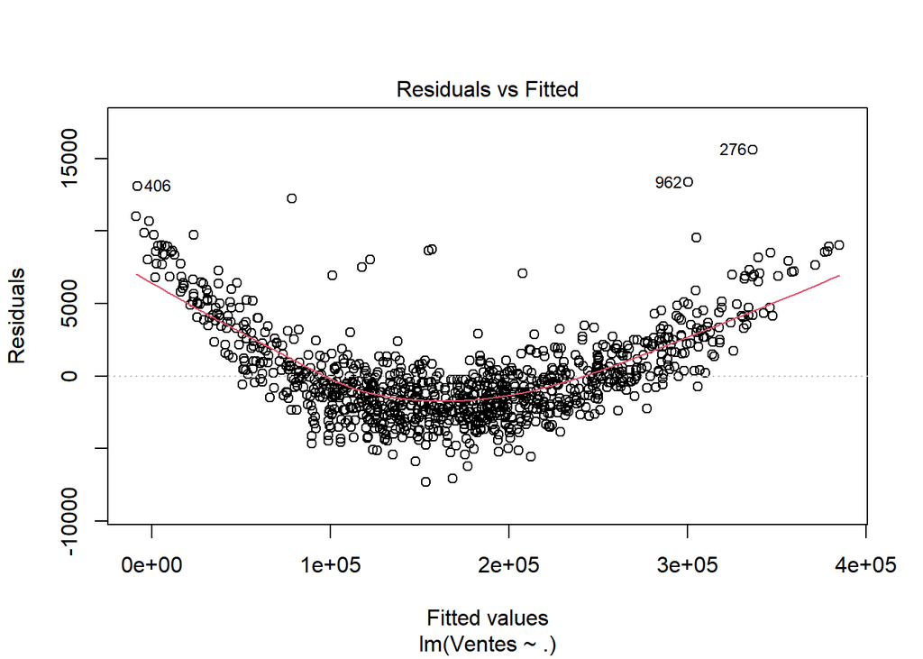

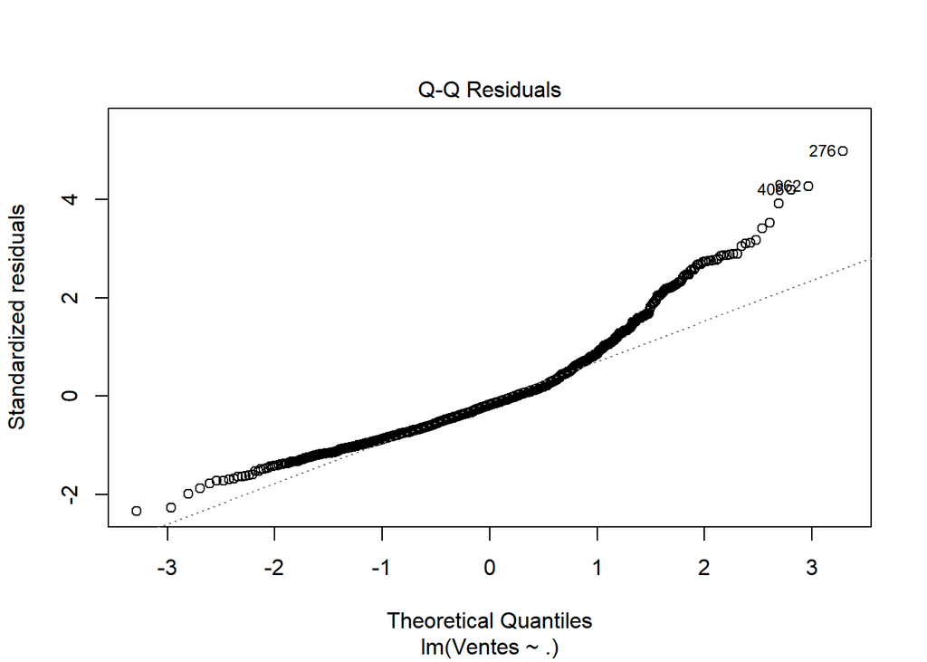

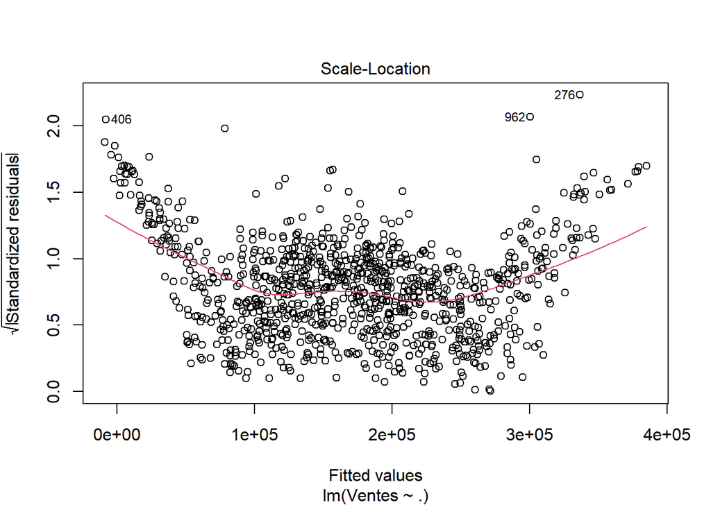

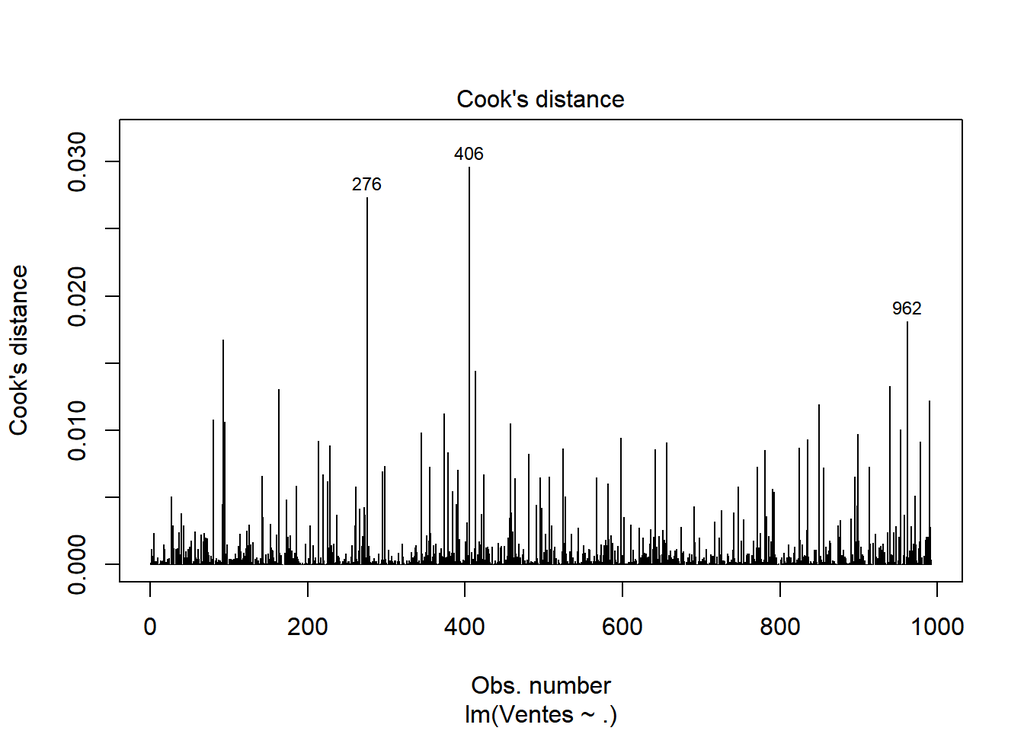

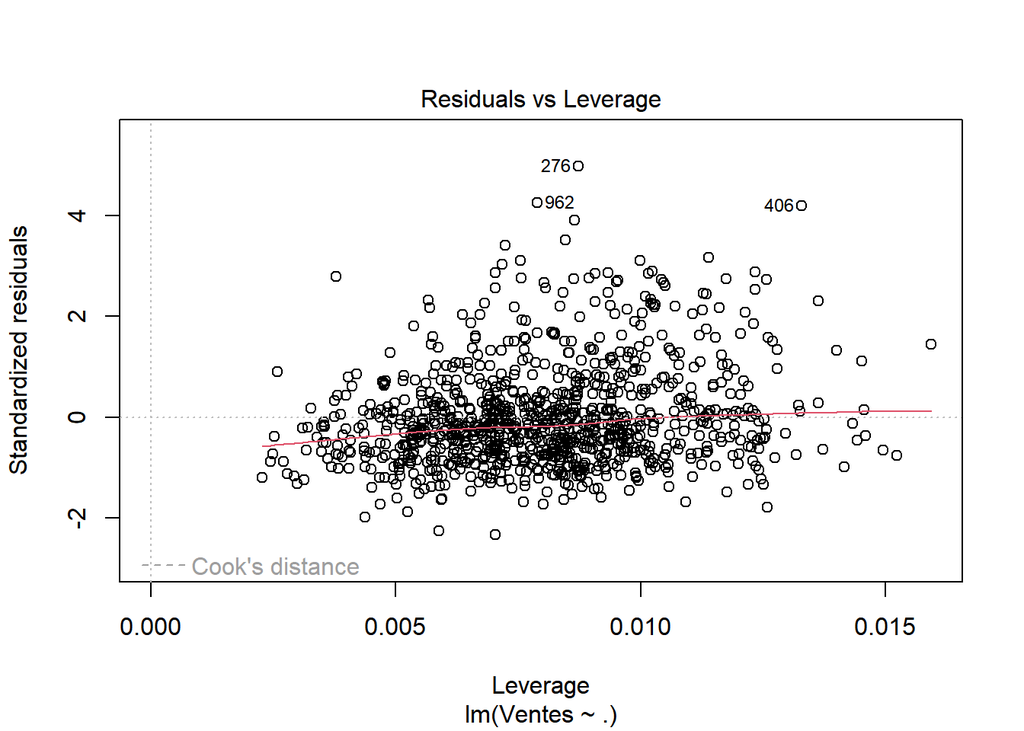

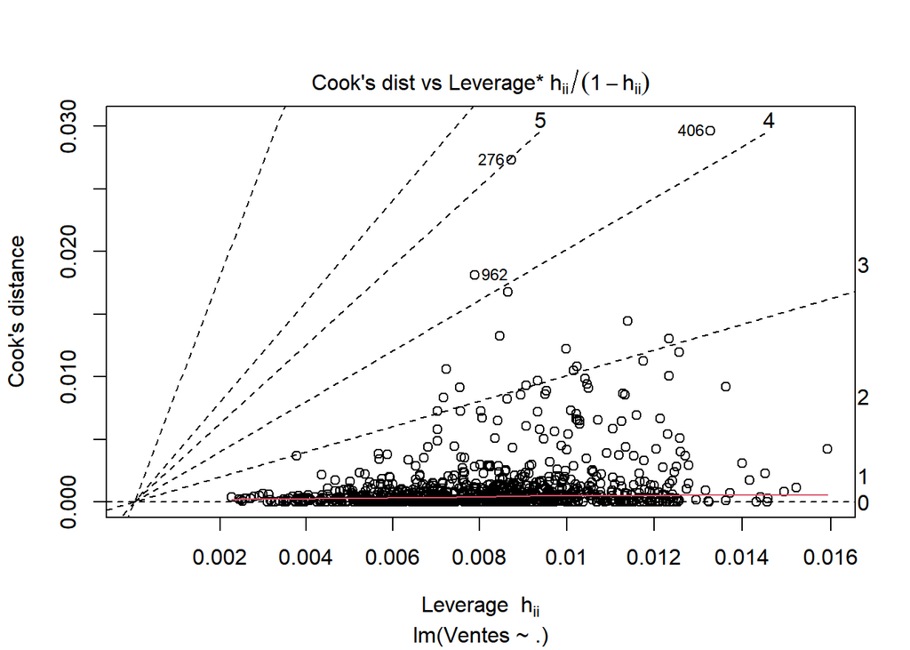

Les résidus ne sont pas répartis de manière aléatoire autour de 0. Cela suggère que le modèle n’est pas linéaire.

### Tests Statistiques

**Test de Rainbow**

Hypothèses :

- $H_0$ : Le modèle est linéaire
- $H_1$ : Le modèle n’est pas linéaire.

```
##
##  Rainbow test
##
## data:  modele
## Rain = 1.1323, df1 = 496, df2 = 488, p-value = 0.08443
```

On accepte l’hypothèse linéarité au rique avec un rique 5% de se tromper.

**Test de Ramsey RESET**

Hypotèses :

- $H_O$: Le modèle est linéaire
- $H_1$: Le modèle est non linéaire

```
##
##  RESET test
##
## data:  modele
## RESET = 978.48, df1 = 2, df2 = 982, p-value < 2.2e-16
```

**Test de Tsay**

Hypotèses :

- $H_O$: Le modèle est linéaire
- $H_1$: Le modèle est non linéaire

```
##
## Call:
## lm(formula = res ~ poly(fitted_values, 2, raw = TRUE))
##
## Residuals:
##     Min      1Q  Median      3Q     Max
## -5402.2 -1124.2   -85.9  1070.4 11421.9
##
## Coefficients:
##                                       Estimate Std. Error t value Pr(>|t|)
## (Intercept)                          7.543e+03  2.248e+02   33.56   <2e-16 ***
## poly(fitted_values, 2, raw = TRUE)1 -1.100e-01  2.687e-03  -40.94   <2e-16 ***
## poly(fitted_values, 2, raw = TRUE)2  3.143e-07  7.391e-09   42.53   <2e-16 ***
## ---
## Signif. codes:  0 '***' 0.001 '**' 0.01 '*' 0.05 '.' 0.1 ' ' 1
##
## Residual standard error: 1864 on 989 degrees of freedom
## Multiple R-squared:  0.6465, Adjusted R-squared:  0.6458
## F-statistic: 904.3 on 2 and 989 DF,  p-value: < 2.2e-16
```

Les deux coefficients sont significatifs (p-value < 2e-16 pour les deux). Cela signifie que la relation entre X et Y n’est pas strictement linéaire.

### V.2 Moyenne des résidus

### Visualisation graphique

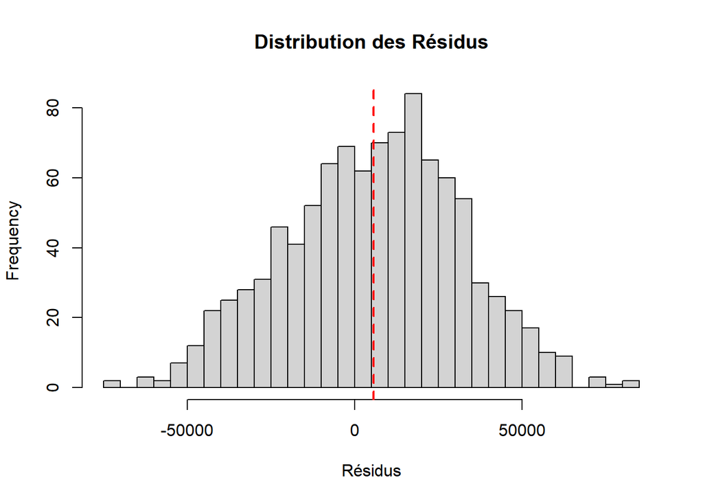

### Tests Statistiques

**Test de Student (t-test)**

Hypothèses :

- $H_0$ : E(ε) = 0(moyenne des erreurs est nulle)
- $H_1$ : E(ε) ≠ 0 (présence d’un biais)

```
##
##  One Sample t-test
##
## data:  epsilon
## t = 6.8156, df = 991, p-value = 1.628e-11
## alternative hypothesis: true mean is not equal to 0
## 95 percent confidence interval:
##  4052.487 7329.636
## sample estimates:
## mean of x
##  5691.062
```

**Interprétation**

```
## [1] "Moyenne des erreurs : 8.65714310274444e-14"
```

### V.3 Homoscédasticité des résidus

### Visualisation graphique

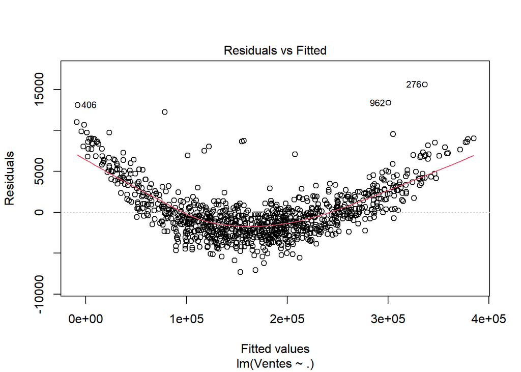

Les résidus ne présentent pas une tendance linéaire donc l’hypothèse d’homoscédasticité semble ne pas être respectée.

### Tests Statistiques

**Test de Breusch-Pagan**

Hypothèses :

- $H_0$ : La variance des résidus est constante (homoscédasticité)
- $H_1$ : La variance des résidus n”est pas constante (hétéroscédasticité)

```
##
##  studentized Breusch-Pagan test
##
## data:  modele
## BP = 12.576, df = 7, p-value = 0.08313
```

Le test de Breusch-Pagan nous permet d’accepter que l’hypothèse d’homoscédasticité.

**Test de Goldfeld-Quandt**

Hypothèses :

- $H_0$ : La variance des résidus est constante (homoscédasticité)
- $H_1$ : La variance des résidus n”est pas constante (hétéroscédasticité)

```
##
##  Goldfeld-Quandt test
##
## data:  modele
## GQ = 0.96898, df1 = 488, df2 = 488, p-value = 0.636
## alternative hypothesis: variance increases from segment 1 to 2
```

P-value > 0.O5, donc on peut dire que la variance des résidus est constante au risque de se tromper de 5%.

### V.4 Corrélation des résidus

### Visualisation graphique : Corrélogramme

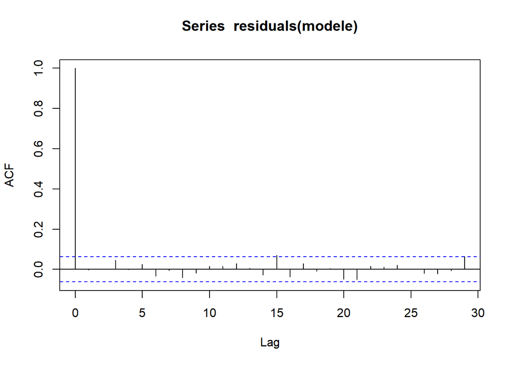

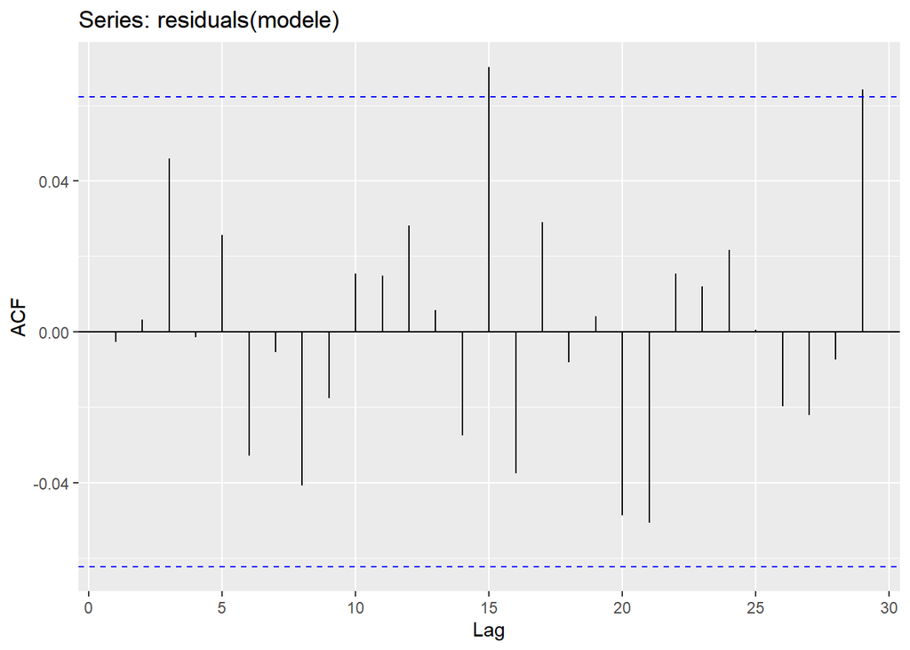

Le test montre que les résidus ne présentent pas d’autocorrélation significative, car la plupart des barres d’autocorrélation sont dans les bandes bleues (intervalle de confiance). Cela indique que le modèle explique correctement la structure des données, sans laisser de dépendance temporelle non prise en compte.

### Tests statistiques

**Test de Durbin-Watson**

Hypothèses :

- $H_0$ : Les résidus ne sont pas autocorrélés
- $H_1$ : Les résidus sont autocorrélés

```
##
##  Durbin-Watson test
##
## data:  modele
## DW = 2.0047, p-value = 0.5306
## alternative hypothesis: true autocorrelation is greater than 0
```

**La statistique DW** proche de 2 et la p-value élevée(O.5306) indiquent qu’il n’y a pas d’autocorrélation significative entre les résidus.

**Test de Ljung-Box**

Hypothèse :

- $H_0$ : Les résidus ne sont pas autocorrélés
- $H_1$ : Les résidus sont autocorrélés

```
##
##  Box-Ljung test
##
## data:  residuals(modele)
## X-squared = 0.0071457, df = 1, p-value = 0.9326
```

On obtient une p-value > 0,05, il n’y pas d’autocorrélation. Les résidus semblent donc être indépendants.

**Test de Box-Pierce**

Hypothèses :

- $H_O$ : Les résidus ne sont pas autocorrélés (ils sont indépendants)
- $H_1$: Les résidus sont autocorrélés (présence d’une dépendance dans les erreurs).

```
## [1] "Box-Pierce p-value: 0.93273460235697"
```

P-value > 0.05, on conclut qu’il n’y a pas d’autocorrélation significative des résidus.

### V.5 Normalité des résidus

### Visualisation graphique

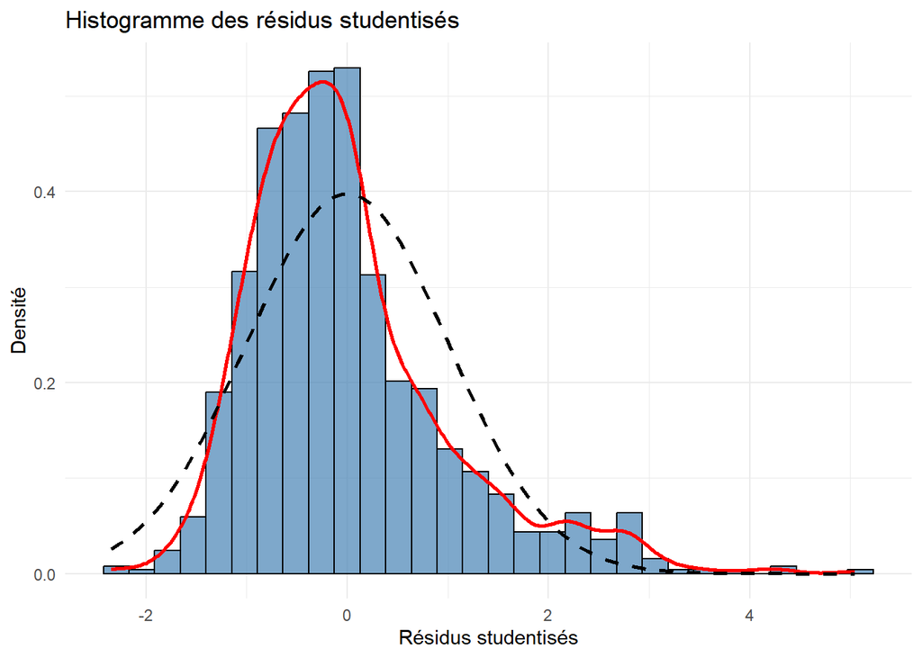

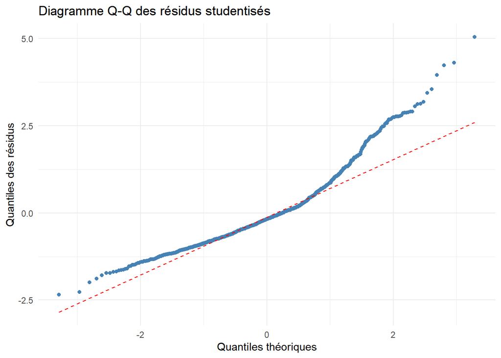

Interprétation :

- La courbe rouge (densité empirique) ne s’aligne pas avec la courbe noire en pointillés (distribution normale théorique), la normalité des résidus est remise en question.
- les points s’éloignent de la ligne rouge, les résidus ne suivent pas une loi normale.

### Tests statistiques

**Test de Shapiro-Wilk**

Hypothèses :

- $H_0$ : Le modèle suit une loi normale
- $H_1$ : Le modèle ne suit pas une loi normale

```
##
##  Shapiro-Wilk normality test
##
## data:  epsilon
## W = 0.92107, p-value < 2.2e-16
```

P-value < 0,05 donc nous concluons que **les résidus ne suivent pas une loi normale**.

**Test de normalité de Lilliefors**

Hypothèses :

- $H_0$: Le modèle suit une loi normale
- $H_1$ : Le modèle ne suit pas une loi normale.

```
## [1] "Lilliefors p-value: 4.71507481628052e-38"
```

P-value < 0.05, donc les résidus ne suivent pas une loi normale.

## **Tableau récapitulatif de nos tests statistiques**

[output not shown]

## VI. Détection des individus extrêmes (outliers)

Nous vérifions la présence des outliers dans notre modèle. Afin de les identifier, nous allons utiliser différentes approches :

- Détection des outliers via l’effet levier (Hat Values) : Détecte les observations éloignées du nuage des données
- Détection des outliers via la distance de Cook : Trouve les points influents globalement sur tout le modèle.
- Détection via les résidus studentisés : Vérifie si les erreurs suivent une distribution normale et sont homogènes.
- Analyse des DFBETAS (Influence sur les coefficients) :Vérifie l’impact des observations sur les coefficients.
- Analyse des DFFITS (Influence sur les prédictions) : Trouve les observations qui faussent leurs propres prédictions.

### VI.1 Détection des outliers via l’effet levier (Hat Values)

L’effet levier est mesuré par la matrice Hat :
$$H = X (X^T X)^{-1} X^T$$
où
$$H$$
représente la diagonale de la matrice Hat.

Une observation est considérée comme influente si :
$$H > \frac{2p}{n}$$

où : - $p$ est le nombre de paramètres du modèle (y compris l’intercept), - $n$ est la taille de l’échantillon.

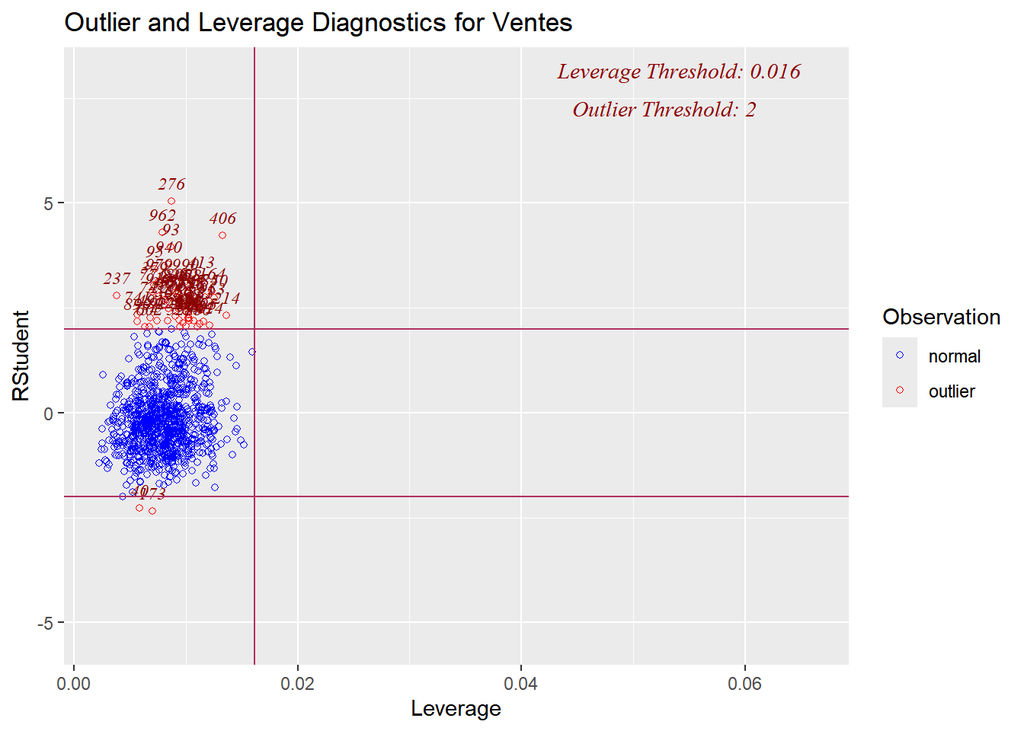

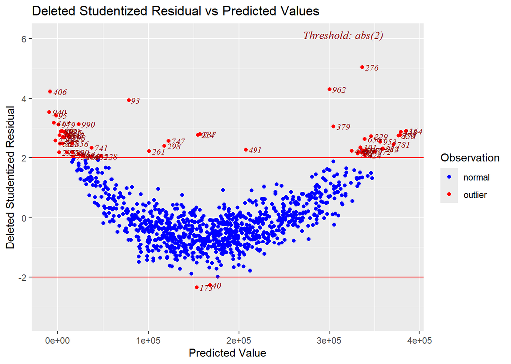

```
## named integer(0)
```

```
##     Min.  1st Qu.   Median     Mean  3rd Qu.     Max.
## 0.002280 0.006411 0.008062 0.008065 0.009569 0.015929
```

```
## [1] 0.03225806
```

Le seuil est trop bas pour detecter les valeurs extrèmes qu’on visualise sur le graphique donc on l’augmente. L’effet levier ne détecte pas d’outliers.

### VI.2 Détection via les résidus studentisés

Les résidus studentisés externes permettent de détecter les valeurs aberrantes :
$$t_i = \frac{e_{(i)}}{s_{(i)}
\sqrt{1 - h_i}}$$
où :

- $e_i$ est le résidu de l’observation $i$ _ $h_i$ est la valeur de levier, $s_{(i)}$ est l’écart-type des résidus calculé sans l’observation $i$.

Une observation est suspecte si $|t_i| > 3$.

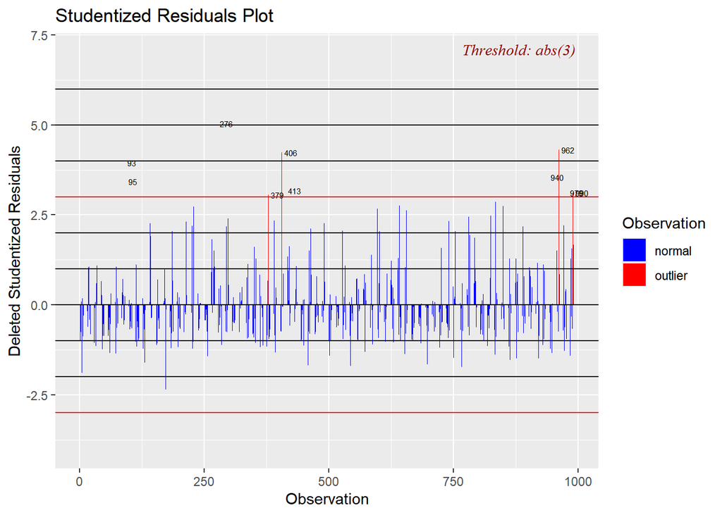

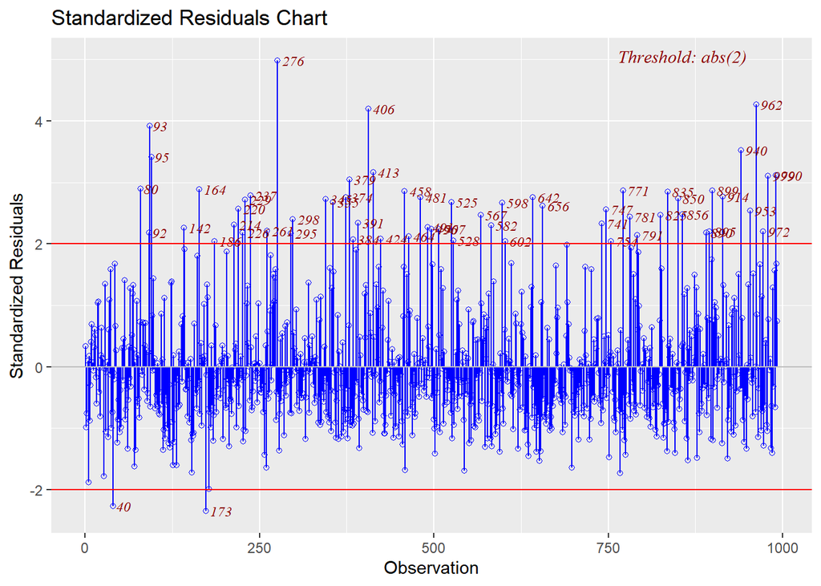

```
## Nombre d'outliers avec |résidu studentisé| > 2 : 61
```

```
## Nombre d'outliers sévères avec |résidu studentisé| > 3 : 10
```